# 📊 BRASFI Survey Analysis — Interim Results

This repository analyzes survey data from **BRASFI — Trilha COP30 Palestras**.  
The workflow is written in **Python**, executed in **RStudio Cloud (via reticulate)**.

## ⚙️ Requirements

- Python packages: `pandas`, `matplotlib`, `seaborn`, `wordcloud`, `openpyxl`
- Environment: RStudio Cloud with **reticulate**

```python
import pandas as pd
import matplotlib.pyplot as plt
import seaborn as sns
from wordcloud import WordCloud, STOPWORDS
```

## 🔍 Data Cleaning & Normalization

- Column names standardized (spaces trimmed).
- Patch applied: responses about **alignment of expectations** recoded into `"Sim"` and `"Não"` for consistency.

```python
# Example: recoding alignment question
df.loc[mask_nao_1 | mask_nao_2, alin_col] = "Não"
df.loc[mask_sim_plain | mask_sim_justa, alin_col] = "Sim"
```

## 📈 Quantitative Visualizations

- **Pie charts** for categorical questions (aggregating small groups as *Outros*).
- **Horizontal bar charts** when categories are long or numerous.

```python
# Example: horizontal bar chart
sns.barplot(x=counts.values, y=counts.index, color="#568203")
plt.xlabel("Frequência")
plt.ylabel("Categoria")
plt.title("Participação em setores da BRASFI")
```

**Interim Results (examples):** - Participation in **sectors/núcleos**: majority answered *Sim*.  
- Preferred **frequency of meetings**: most chose *Quinzenal*.  
- Accessibility of **schedule (quartas, 19h)**: mixed responses, with many requesting alternatives.

📊 Example output:

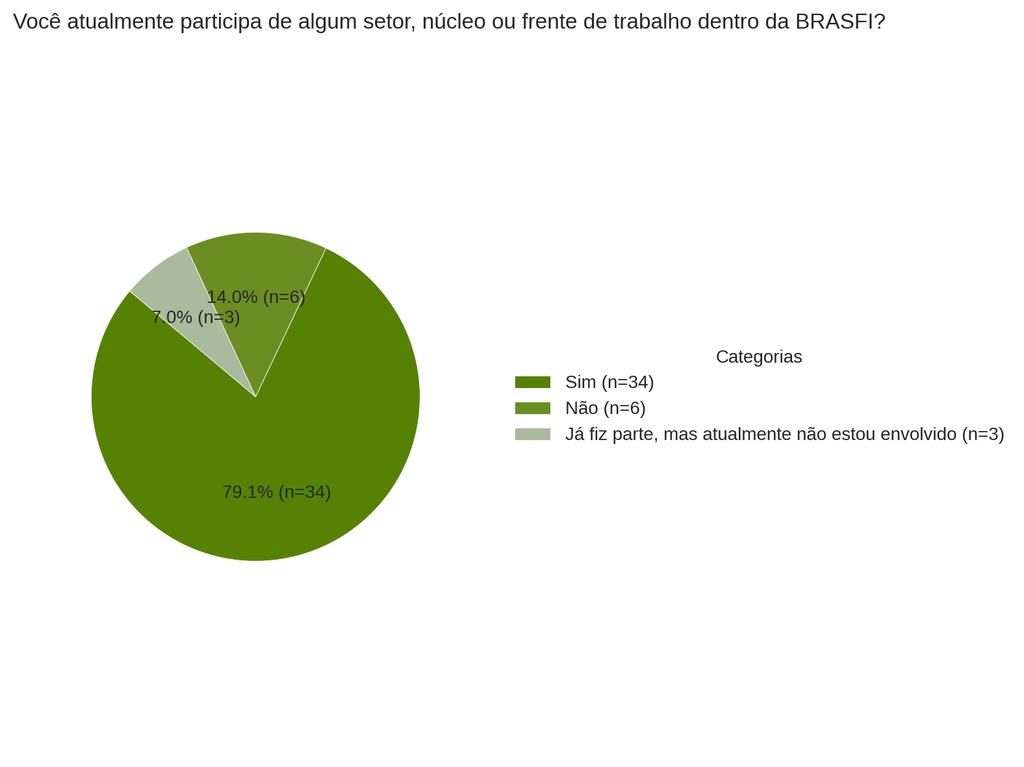

## ☁️ Word Clouds for Open Questions

```python
wc = WordCloud(width=1000, height=500,
               background_color="white",
               stopwords=stopwords,
               colormap="summer").generate(text)
```

☁️ Example output:

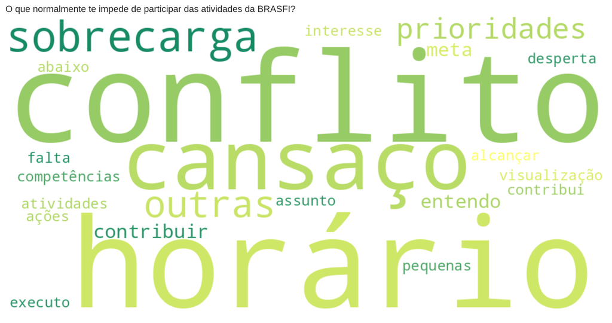

[figure not shown]

## 📂 Outputs

- **Charts** → `charts/` (pie charts, bar charts)
- **Word clouds** → `wordclouds/` (one per open question)
- **Legends** → `legends/` (TXT/CSV/PNG files mapping numeric codes to categories)

## 📝 Next Steps

- Expand qualitative coding from word clouds into **thematic clusters**.
- Incorporate **summary tables** (top 10 words per question).
- Prepare **presentation-ready plots** for reporting.